# A5 Decision Trees

Luke Ghallahorne

2025-02-12

```r
# Library
library(tidyverse)
library(C50)
library(caret)
```

# The Data

```r
# read in data
mush <- read_csv("mushroomsClean.csv")
mush <- mush |>
  mutate(across(where(is_character), as_factor))
str(mush)
```

```
## tibble [8,124 × 21] (S3: tbl_df/tbl/data.frame)
##  $ toxicity           : Factor w/ 2 levels "poison","edible": 1 2 2 1 2 2 2 2 1 2 ...
##  $ cap_shape          : Factor w/ 4 levels "convex","sunken",..: 1 1 2 1 1 1 2 2 1 2 ...
##  $ cap_surface        : Factor w/ 4 levels "smooth","scaly",..: 1 1 1 2 1 2 1 2 2 1 ...
##  $ cap_color          : Factor w/ 10 levels "brown","yellow",..: 1 2 3 3 4 2 3 3 3 2 ...
##  $ bruises            : Factor w/ 2 levels "yes","no": 1 1 1 1 2 1 1 1 1 1 ...
##  $ gill_attach        : Factor w/ 2 levels "free","attached": 1 1 1 1 1 1 1 1 1 1 ...
##  $ gill_spacing       : Factor w/ 2 levels "close","crowded": 1 1 1 1 2 1 1 1 1 1 ...
##  $ gill_size          : Factor w/ 2 levels "narrow","broad": 1 2 2 1 2 2 2 2 1 2 ...
##  $ gill_color         : Factor w/ 12 levels "black","brown",..: 1 1 2 2 1 2 3 2 4 3 ...
##  $ stalk_shape        : Factor w/ 2 levels "enlarging","tapering": 1 1 1 1 2 1 1 1 1 1 ...
##  $ stalk_root         : Factor w/ 5 levels "equal","club",..: 1 2 2 1 1 2 2 2 1 2 ...
##  $ stalk_surface_above: Factor w/ 3 levels "smooth","fibrous",..: 1 1 1 1 1 1 1 1 1 1 ...
##  $ stalk_surface_below: Factor w/ 3 levels "smooth","fibrous",..: 1 1 1 1 1 1 1 1 1 1 ...
##  $ stalk_color_above  : Factor w/ 9 levels "white","gray",..: 1 1 1 1 1 1 1 1 1 1 ...
##  $ stalk_color_below  : Factor w/ 9 levels "white","pink",..: 1 1 1 1 1 1 1 1 1 1 ...
##  $ veil_color         : Factor w/ 4 levels "white","brown",..: 1 1 1 1 1 1 1 1 1 1 ...
##  $ ring_number        : Factor w/ 3 levels "one","two","none": 1 1 1 1 1 1 1 1 1 1 ...
##  $ ring_type          : Factor w/ 5 levels "pendant","evanescent",..: 1 1 1 1 2 1 1 1 1 1 ...
##  $ spore_print_color  : Factor w/ 9 levels "black","brown",..: 1 2 2 1 2 1 1 2 1 1 ...
##  $ population         : Factor w/ 6 levels "scattered","numerous",..: 1 2 2 1 3 2 2 1 4 1 ...
##  $ habitat            : Factor w/ 7 levels "urban","grasses",..: 1 2 3 1 2 2 3 3 2 3 ...
```

I would like to model toxicity using decision trees based on a number of variables that seem reasonable. By reasonable, I mean variables that I think I would be able to distinguish about a mushroom (definitely not a mycologist either) in order to make a model I would feel confident trusting.

Of the 21 variables provided in the data, I think the following would be noticeable by an average mushroom-eater: cap_shape, cap_color, bruises, gill_color, stalk_shape, stalk_color_above, stalk_color_below, population, and habitat.

```r
mush_clean <- mush |>
  select(toxicity,
         cap_shape, cap_color, bruises, gill_color, stalk_shape,
         stalk_color_above,  stalk_color_below, population, habitat)
```

# Decision Tree

```r
mush_model <- C5.0(toxicity~., data = mush_clean)
mush_model
```

```
##
## Call:
## C5.0.formula(formula = toxicity ~ ., data = mush_clean)
##
## Classification Tree
## Number of samples: 8124
## Number of predictors: 9
##
## Tree size: 33
##
## Non-standard options: attempt to group attributes
```

```r
summary(mush_model)
```

```
##
## Call:
## C5.0.formula(formula = toxicity ~ ., data = mush_clean)
##
##
## C5.0 [Release 2.07 GPL Edition]      Wed Feb 12 17:28:46 2025
## -------------------------------
##
## Class specified by attribute `outcome'
##
## Read 8124 cases (10 attributes) from undefined.data
##
## Decision tree:
##
## gill_color in {buff,green}: poison (1752/34)
## gill_color in {black,brown,gray,pink,white,chocolate,purple,red,yellow,orange}:
## :...stalk_color_above in {brown,buff,cinnamon,yellow}:
##     :...cap_color in {yellow,white,gray,red,pink,buff,purple,cinnamon,
##     :   :             green}: poison (896/20)
##     :   cap_color = brown:
##     :   :...stalk_color_above in {brown,buff,yellow}: edible (16/1)
##     :       stalk_color_above = cinnamon: poison (12)
##     stalk_color_above in {white,gray,pink,red,orange}:
##     :...habitat = urban:
##         :...bruises = yes: poison (272/4)
##         :   bruises = no: edible (96/3)
##         habitat in {grasses,meadows,woods,paths,waste,leaves}:
##         :...stalk_shape = tapering:
##             :...habitat in {meadows,woods,paths,waste,
##             :   :           leaves}: edible (1824/30)
##             :   habitat = grasses:
##             :   :...bruises = yes: poison (144/2)
##             :       bruises = no: edible (768/14)
##             stalk_shape = enlarging:
##             :...stalk_color_above = gray: edible (0)
##                 stalk_color_above = pink: poison (432/5)
##                 stalk_color_above in {white,red,orange}:
##                 :...habitat = woods:
##                     :...cap_color in {purple,green}: edible (32/1)
##                     :   cap_color in {brown,yellow,red,buff,
```

[output cut: 67 more lines]

```
##
##  Attribute usage:
##
##  100.00% gill_color
##   78.43% stalk_color_above
##   67.06% habitat
##   62.53% stalk_shape
##   22.65% population
##   21.61% cap_color
##   15.76% bruises
##    9.95% stalk_color_below
##    9.45% cap_shape
##
##
## Time: 0.0 secs
```

Impressively, buff gill color is a huge indicator of toxicity. Now if only I knew which color “buff” was… Gill color, stalk color, and cap color look like they are dominating the first few decisions, but from there general categories seem irrelevant as you go from one decision to the next.

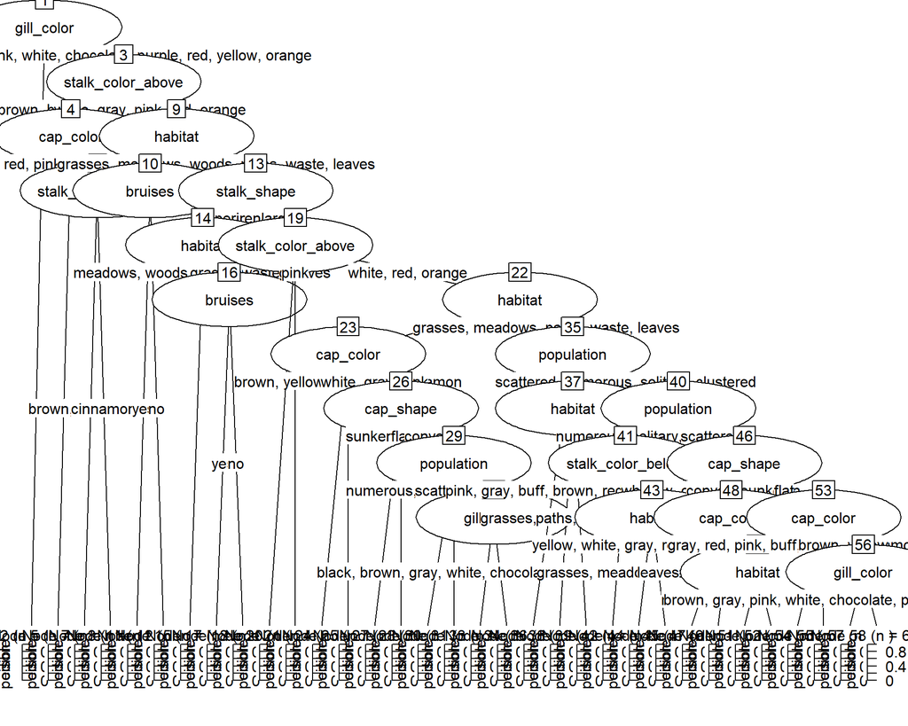

```r
plot(mush_model)
```

I was curious how base-plot would render this, and I am not impressed. I’m hoping to come back to this and rework the visualization once I complete the assignment.

# Training and Testing

```r
n <- nrow(mush)
rows2test <- sample(n, size = 0.3 * n)
mush_train <- mush[-rows2test,]
mush_test <- mush[rows2test,]


mush_model2 <- C5.0(toxicity ~ ., data = mush_train)
mush_fits <- predict(mush_model2, mush_test)
mush_cm <- confusionMatrix(mush_fits, mush_test$toxicity)
mush_cm
```

```
## Confusion Matrix and Statistics
##
##           Reference
## Prediction poison edible
##     poison   1113     18
##     edible     32   1274
##
##                Accuracy : 0.9795
##                  95% CI : (0.973, 0.9847)
##     No Information Rate : 0.5302
##     P-Value [Acc > NIR] : < 2e-16
##
##                   Kappa : 0.9588
##
##  Mcnemar's Test P-Value : 0.06599
##
##             Sensitivity : 0.9721
##             Specificity : 0.9861
##          Pos Pred Value : 0.9841
##          Neg Pred Value : 0.9755
##              Prevalence : 0.4698
##          Detection Rate : 0.4567
##    Detection Prevalence : 0.4641
##       Balanced Accuracy : 0.9791
##
##        'Positive' Class : poison
##
```

The model numerically does very well, with an accuracy of 0.979. However, a little less than 3 percent of the time, the model classifies a poisonous mushroom as being edible. I eat a lot of mushrooms, so 3 percent, while not being very large statistically, is a little too high for my taste. This is only a single test-train set, too, so repeated cross validation might reduce that value and leave me a little more confident in the model. I would definitely want to refine the model before using it to gauge how edible an unknown mushroom was.